# Regression Model for Metro Interstate Traffic Volume Using R Take 4

David Lowe

September 9, 2019

Template Credit: Adapted from a template made available by Dr. Jason Brownlee of Machine Learning Mastery. [http://machinelearningmastery.com/]

SUMMARY: The purpose of this project is to construct a predictive model using various machine learning algorithms and to document the end-to-end steps using a template. The Metro Interstate Traffic Volume is a regression situation where we are trying to predict a real-number value for a given set of criteria.

INTRODUCTION: This dataset captured the hourly measurement of Interstate 94 Westbound traffic volume for MN DoT ATR station 301. The station is roughly midway between Minneapolis and St Paul, MN. The dataset also included the hourly weather and holiday attributes for assessing their impacts on traffic volume.

In iteration Take1, we established the baseline mean squared error without much of feature engineering. This round of modeling also did not include the date-time and weather description attributes.

In iteration Take2, we included the time stamp feature and observed its effect on improving the prediction accuracy.

In iteration Take3, we re-engineered (scale and/or discretize) the weather-related features and observed their effect on the prediction accuracy.

In this iteration, we will re-engineer (scale and/or binarize) the holiday and weather-related features and observe their effect on the prediction accuracy.

From iteration Take2, the baseline performance of the machine learning algorithms achieved an average RMSE of 972. Two algorithms (Random Forest and Gradient Boosting) achieved the top RMSE metrics after the first round of modeling. After a series of tuning trials, Gradient Boosting turned in the top overall result and achieved an RMSE metric of 480. After applying the optimized parameters, the Gradient Boosting algorithm processed the testing dataset with an RMSE of 479, which was slightly better than the prediction from the training data.

By including the date_time information and related attributes, the machine learning models did a significantly better job in prediction with a much lower RMSE.

From iteration Take3, the baseline performance of the machine learning algorithms achieved an average RMSE of 814. Two algorithms (Random Forest and Gradient Boosting) achieved the top RMSE metrics after the first round of modeling. After a series of tuning trials, Random Forest turned in the top overall result and achieved an RMSE metric of 474. After applying the optimized parameters, the Random Forest algorithm processed the testing dataset with an RMSE of 472, which was slightly better than the prediction from the training data.

By re-engineering the weather-related features, the average performance of all models did better. However, the changes appeared to have little impact on the performance of the ensemble algorithms.

By re-engineering the holiday and other weather-related features, the average performance of all models did better than baseline. Moreover, the changes appeared to have further positive impact on the performance of the Random Forest ensemble algorithm.

CONCLUSION: For this iteration, the Random Forest algorithm achieved the best overall training and validation results. For this dataset, the Random Forest algorithm could be considered for further modeling.

Dataset Used: Metro Interstate Traffic Volume Data Set

Dataset ML Model: Regression with numerical and categorical attributes

Dataset Reference: https://archive.ics.uci.edu/ml/datasets/Metro+Interstate+Traffic+Volume

One potential source of performance benchmarks: https://www.kaggle.com/ramyahr/metro-interstate-traffic-volume

The project aims to touch on the following areas:

1. Document a predictive modeling problem end-to-end.
2. Explore data cleaning and transformation options
3. Explore non-ensemble and ensemble algorithms for baseline model performance
4. Explore algorithm tuning techniques for improving model performance

Any predictive modeling machine learning project genrally can be broken down into about six major tasks:

1. Prepare Environment
2. Summarize Data
3. Prepare Data
4. Model and Evaluate Algorithms
5. Improve Accuracy or Results
6. Finalize Model and Present Results

## 1. Prepare Environment

### 1.a) Load libraries and packages

```r
startTimeScript <- proc.time()
library(caret)
```

```r
library(corrplot)
library(DMwR)
library(Hmisc)
library(ROCR)
library(stringr)
```

### 1.b) Set up the controlling parameters and functions

```r
# Create the random seed number for reproducible results
seedNum <- 888

# Set up the notifyStatus flag to stop sending progress emails (setting to TRUE will send status emails!)
notifyStatus <- TRUE
if (notifyStatus) library(mailR)
# Run algorithms using 10-fold cross validation
control <- trainControl(method="repeatedcv", number=10, repeats=1)
metricTarget <- "RMSE"
```

```r
# Set up the email notification function
email_notify <- function(msg=""){
  sender <- Sys.getenv("MAIL_SENDER")
  receiver <- Sys.getenv("MAIL_RECEIVER")
  gateway <- Sys.getenv("SMTP_GATEWAY")
  smtpuser <- Sys.getenv("SMTP_USERNAME")
  password <- Sys.getenv("SMTP_PASSWORD")
  sbj_line <- "Notification from R Regression Modeling Script"
  send.mail(
    from = sender,
    to = receiver,
    subject= sbj_line,
    body = msg,
    smtp = list(host.name = gateway, port = 587, user.name = smtpuser, passwd = password, ssl = TRUE),
    authenticate = TRUE,
    send = TRUE)
}
```

```r
if (notifyStatus) email_notify(paste("Library and Data Loading has begun!",date()))
```

```
## [1] "Java-Object{org.apache.commons.mail.SimpleEmail@3b6eb2ec}"
```

### 1.c) Load dataset

```r
# Slicing up the document path to get the final destination file name
dataset_path <- 'https://archive.ics.uci.edu/ml/machine-learning-databases/00492/Metro_Interstate_Traffic_Volume.csv.gz'
doc_path_list <- str_split(dataset_path, "/")
# dest_file <- doc_path_list[[1]][length(doc_path_list[[1]])]
dest_file <- "Metro_Interstate_Traffic_Volume.csv"

if (!file.exists(dest_file)) {
  # Download the document from the website
  cat("Downloading", dataset_path, "as", dest_file, "\n")
  download.file(dataset_path, dest_file, mode = "wb")
  cat(dest_file, "downloaded!\n")
  unzip(dest_file)
  cat(dest_file, "unpacked!\n")
}

inputFile <- dest_file
Xy_original <- read.csv(dest_file, header = TRUE, stringsAsFactors = FALSE)
```

```r
# Take a peek at the dataframe after the import
head(Xy_original)
```

```
##   holiday   temp rain_1h snow_1h clouds_all weather_main
## 1    None 288.28       0       0         40       Clouds
## 2    None 289.36       0       0         75       Clouds
## 3    None 289.58       0       0         90       Clouds
## 4    None 290.13       0       0         90       Clouds
## 5    None 291.14       0       0         75       Clouds
## 6    None 291.72       0       0          1        Clear
##   weather_description           date_time traffic_volume
## 1    scattered clouds 2012-10-02 09:00:00           5545
## 2       broken clouds 2012-10-02 10:00:00           4516
## 3     overcast clouds 2012-10-02 11:00:00           4767
## 4     overcast clouds 2012-10-02 12:00:00           5026
## 5       broken clouds 2012-10-02 13:00:00           4918
## 6        sky is clear 2012-10-02 14:00:00           5181
```

```r
summary(Xy_original)
```

```
##    holiday               temp          rain_1h            snow_1h
##  Length:48204       Min.   :  0.0   Min.   :   0.000   Min.   :0.0000000
##  Class :character   1st Qu.:272.2   1st Qu.:   0.000   1st Qu.:0.0000000
##  Mode  :character   Median :282.4   Median :   0.000   Median :0.0000000
##                     Mean   :281.2   Mean   :   0.334   Mean   :0.0002224
##                     3rd Qu.:291.8   3rd Qu.:   0.000   3rd Qu.:0.0000000
##                     Max.   :310.1   Max.   :9831.300   Max.   :0.5100000
##    clouds_all     weather_main       weather_description
##  Min.   :  0.00   Length:48204       Length:48204
##  1st Qu.:  1.00   Class :character   Class :character
##  Median : 64.00   Mode  :character   Mode  :character
##  Mean   : 49.36
##  3rd Qu.: 90.00
##  Max.   :100.00
##   date_time         traffic_volume
##  Length:48204       Min.   :   0
##  Class :character   1st Qu.:1193
##  Mode  :character   Median :3380
##                     Mean   :3260
##                     3rd Qu.:4933
##                     Max.   :7280
```

```r
sapply(Xy_original, class)
```

```
##             holiday                temp             rain_1h
##         "character"           "numeric"           "numeric"
##             snow_1h          clouds_all        weather_main
##           "numeric"           "integer"         "character"
## weather_description           date_time      traffic_volume
##         "character"         "character"           "integer"
```

```r
sapply(Xy_original, function(x) sum(is.na(x)))
```

```
##             holiday                temp             rain_1h
##                   0                   0                   0
##             snow_1h          clouds_all        weather_main
##                   0                   0                   0
## weather_description           date_time      traffic_volume
##                   0                   0                   0
```

### 1.d) Data Cleaning

```r
# Create new columns from the date_time attribute
Xy_original$date_time <- strptime(Xy_original$date_time, "%Y-%m-%d %H:%M:%S")
Xy_original$date_string <- strftime(Xy_original$date_time, "%Y-%m-%d")
Xy_original$date_month <- months(Xy_original$date_time)
Xy_original$date_month <- as.factor(Xy_original$date_month)
Xy_original$date_weekday <- weekdays(Xy_original$date_time)
Xy_original$date_weekday <- as.factor(Xy_original$date_weekday)
Xy_original$date_hour <- strftime(Xy_original$date_time, "%H")
Xy_original$date_hour <- as.factor(Xy_original$date_hour)
Xy_original$targetVar <- Xy_original$traffic_volume

# Clean up the incorrect holiday entries
date_vec <- vector()
holiday_vec <- vector()
for (row in 1:nrow(Xy_original)) {
  thisDate <- Xy_original[row, "date_string"]
  thisHoliday <- Xy_original[row, "holiday"]
  if (thisHoliday != "None") {
    date_vec <- c(date_vec, thisDate)
    holiday_vec <- c(holiday_vec, thisHoliday)
  }
}
holiday_dict <- setNames(holiday_vec, date_vec)
for (lookupDate in names(holiday_dict)) {
  Xy_original$holiday[Xy_original$date_string == lookupDate] <- holiday_dict[[lookupDate]]
}

# Re-engineer the weather related attributes
# Rescale the temperature in Kelvin to Celcius & correct some zero degree Kelvin entries
mean_temp = mean(Xy_original$temp)
Xy_original$temp[Xy_original$temp == 0] <- mean_temp
Xy_original$temp = Xy_original$temp - 272.15
# Reset one row with rainfall of 9831.3 mm to the max of 55.63
max_rain = 55.63
Xy_original$rain_1h[Xy_original$rain_1h > 100] <- max_rain

# Convert columns from string data type to factor
Xy_original$holiday <- as.factor(Xy_original$holiday)
Xy_original$weather_main <- as.factor(Xy_original$weather_main)

# Drop un-needed features
Xy_original$date_time <- NULL
Xy_original$date_string <- NULL
Xy_original$weather_description <- NULL
Xy_original$traffic_volume <- NULL
```

```r
# Take a peek at the dataframe after the cleaning
head(Xy_original)
```

```
##   holiday  temp rain_1h snow_1h clouds_all weather_main date_month
## 1    None 16.13       0       0         40       Clouds    October
## 2    None 17.21       0       0         75       Clouds    October
## 3    None 17.43       0       0         90       Clouds    October
## 4    None 17.98       0       0         90       Clouds    October
## 5    None 18.99       0       0         75       Clouds    October
## 6    None 19.57       0       0          1        Clear    October
##   date_weekday date_hour targetVar
## 1      Tuesday        09      5545
## 2      Tuesday        10      4516
## 3      Tuesday        11      4767
## 4      Tuesday        12      5026
## 5      Tuesday        13      4918
## 6      Tuesday        14      5181
```

```r
summary(Xy_original)
```

```
##                  holiday           temp            rain_1h
##  None                :46795   Min.   :-28.760   Min.   : 0.0000
##  Labor Day           :  157   1st Qu.:  0.040   1st Qu.: 0.0000
##  Washingtons Birthday:  136   Median : 10.300   Median : 0.0000
##  Thanksgiving Day    :  135   Mean   :  9.114   Mean   : 0.1315
##  Memorial Day        :  134   3rd Qu.: 19.656   3rd Qu.: 0.0000
##  Christmas Day       :  131   Max.   : 37.920   Max.   :55.6300
##  (Other)             :  716
##     snow_1h            clouds_all      weather_main      date_month
##  Min.   :0.0000000   Min.   :  0.00   Clouds :15164   July    : 4795
##  1st Qu.:0.0000000   1st Qu.:  1.00   Clear  :13391   May     : 4436
##  Median :0.0000000   Median : 64.00   Mist   : 5950   August  : 4378
##  Mean   :0.0002224   Mean   : 49.36   Rain   : 5672   April   : 4259
##  3rd Qu.:0.0000000   3rd Qu.: 90.00   Snow   : 2876   December: 4249
##  Max.   :0.5100000   Max.   :100.00   Drizzle: 1821   January : 4006
##                                       (Other): 3330   (Other) :22081
##     date_weekday    date_hour       targetVar
##  Friday   :6836   04     : 2091   Min.   :   0
##  Monday   :7072   06     : 2087   1st Qu.:1193
##  Saturday :6831   08     : 2080   Median :3380
##  Sunday   :6872   07     : 2079   Mean   :3260
##  Thursday :6817   10     : 2078   3rd Qu.:4933
##  Tuesday  :6846   05     : 2063   Max.   :7280
##  Wednesday:6930   (Other):35726
```

```r
sapply(Xy_original, class)
```

```
##      holiday         temp      rain_1h      snow_1h   clouds_all
##     "factor"    "numeric"    "numeric"    "numeric"    "integer"
## weather_main   date_month date_weekday    date_hour    targetVar
##     "factor"     "factor"     "factor"     "factor"    "integer"
```

```r
sapply(Xy_original, function(x) sum(is.na(x)))
```

```
##      holiday         temp      rain_1h      snow_1h   clouds_all
##            0            0            0            0            0
## weather_main   date_month date_weekday    date_hour    targetVar
##            0            0            0            0            0
```

### 1.e) Splitting Data into Training and Test Sets

```r
# Use variable totCol to hold the number of columns in the dataframe
totCol <- ncol(Xy_original)

# Set up variable totAttr for the total number of attribute columns
totAttr <- totCol-1
```

```r
# targetCol variable indicates the column location of the target/class variable
# If the first column, set targetCol to 1. If the last column, set targetCol to totCol
# if (targetCol <> 1) and (targetCol <> totCol), be aware when slicing up the dataframes for visualization!
targetCol <- totCol

# Standardize the class column to the name of targetVar if applicable
colnames(Xy_original)[targetCol] <- "targetVar"
```

```r
# Create various sub-datasets for visualization and cleaning/transformation operations.
set.seed(seedNum)

# Use 75% of the data to train the models and the remaining for testing/validation
training_index <- createDataPartition(Xy_original$targetVar, p=0.75, list=FALSE)
Xy_train <- Xy_original[training_index,]
Xy_test <- Xy_original[-training_index,]

if (targetCol==1) {
  X_train <- Xy_train[,(targetCol+1):totCol]
  y_train <- Xy_train[,targetCol]
  y_test <- Xy_test[,targetCol]
} else {
  X_train <- Xy_train[,1:(totAttr)]
  y_train <- Xy_train[,totCol]
  y_test <- Xy_test[,totCol]
}
```

### 1.f) Set up the parameters for data visualization

```r
# Set up the number of row and columns for visualization display. dispRow * dispCol should be >= totAttr
dispCol <- 4
if (totAttr%%dispCol == 0) {
dispRow <- totAttr%/%dispCol
} else {
dispRow <- (totAttr%/%dispCol) + 1
}
cat("Will attempt to create graphics grid (col x row): ", dispCol, ' by ', dispRow)
```

```
## Will attempt to create graphics grid (col x row):  4  by  3
```

```r
if (notifyStatus) email_notify(paste("Library and Data Loading completed!",date()))
```

```
## [1] "Java-Object{org.apache.commons.mail.SimpleEmail@30c7da1e}"
```

## 2. Summarize Data

To gain a better understanding of the data that we have on-hand, we will leverage a number of descriptive statistics and data visualization techniques. The plan is to use the results to consider new questions, review assumptions, and validate hypotheses that we can investigate later with specialized models.

```r
if (notifyStatus) email_notify(paste("Data Summarization and Visualization has begun!",date()))
```

```
## [1] "Java-Object{org.apache.commons.mail.SimpleEmail@2812cbfa}"
```

### 2.a) Descriptive statistics

#### 2.a.i) Peek at the data itself

```r
head(Xy_train)
```

```
##    holiday  temp rain_1h snow_1h clouds_all weather_main date_month
## 2     None 17.21       0       0         75       Clouds    October
## 3     None 17.43       0       0         90       Clouds    October
## 4     None 17.98       0       0         90       Clouds    October
## 5     None 18.99       0       0         75       Clouds    October
## 8     None 21.71       0       0          1        Clear    October
## 11    None 18.82       0       0         20       Clouds    October
##    date_weekday date_hour targetVar
## 2       Tuesday        10      4516
## 3       Tuesday        11      4767
## 4       Tuesday        12      5026
## 5       Tuesday        13      4918
## 8       Tuesday        16      6015
## 11      Tuesday        19      3539
```

#### 2.a.ii) Dimensions of the dataset

```r
dim(Xy_train)
```

```
## [1] 36154    10
```

#### 2.a.iii) Types of the attribute

```r
sapply(Xy_train, class)
```

```
##      holiday         temp      rain_1h      snow_1h   clouds_all
##     "factor"    "numeric"    "numeric"    "numeric"    "integer"
## weather_main   date_month date_weekday    date_hour    targetVar
##     "factor"     "factor"     "factor"     "factor"    "integer"
```

#### 2.a.iv) Statistical summary of the attributes

```r
summary(Xy_train)
```

```
##              holiday           temp             rain_1h
##  None            :35070   Min.   :-27.9300   Min.   : 0.0000
##  Labor Day       :  127   1st Qu.:  0.0025   1st Qu.: 0.0000
##  Christmas Day   :  104   Median : 10.4000   Median : 0.0000
##  Independence Day:   99   Mean   :  9.1324   Mean   : 0.1318
##  New Years Day   :   98   3rd Qu.: 19.6700   3rd Qu.: 0.0000
##  Thanksgiving Day:   98   Max.   : 37.9200   Max.   :55.6300
##  (Other)         :  558
##     snow_1h            clouds_all      weather_main      date_month
##  Min.   :0.0000000   Min.   :  0.00   Clouds :11422   July    : 3570
##  1st Qu.:0.0000000   1st Qu.:  1.00   Clear  : 9975   May     : 3338
##  Median :0.0000000   Median : 64.00   Mist   : 4485   August  : 3280
##  Mean   :0.0001895   Mean   : 49.43   Rain   : 4249   December: 3250
##  3rd Qu.:0.0000000   3rd Qu.: 90.00   Snow   : 2176   April   : 3174
##  Max.   :0.5100000   Max.   :100.00   Drizzle: 1349   January : 3004
##                                       (Other): 2498   (Other) :16538
##     date_weekday    date_hour       targetVar
##  Friday   :5075   07     : 1580   Min.   :   0
##  Monday   :5316   04     : 1575   1st Qu.:1193
##  Saturday :5117   06     : 1562   Median :3380
##  Sunday   :5159   10     : 1557   Mean   :3259
##  Thursday :5138   08     : 1550   3rd Qu.:4933
##  Tuesday  :5149   01     : 1546   Max.   :7280
##  Wednesday:5200   (Other):26784
```

#### 2.a.v) Count missing values

```r
sapply(Xy_train, function(x) sum(is.na(x)))
```

```
##      holiday         temp      rain_1h      snow_1h   clouds_all
##            0            0            0            0            0
## weather_main   date_month date_weekday    date_hour    targetVar
##            0            0            0            0            0
```

### 2.b) Data visualizations

```r
# Boxplots for each attribute
# par(mfrow=c(dispRow,dispCol))
# for(i in 1:totAttr) {
#   boxplot(X_train[,i], main=names(X_train)[i])
# }
```

```r
# Histograms each attribute
# par(mfrow=c(dispRow,dispCol))
# for(i in 1:totAttr) {
#   hist(X_train[,i], main=names(X_train)[i])
# }
```

```r
# Density plot for each attribute
# par(mfrow=c(dispRow,dispCol))
# for(i in 1:totAttr) {
#   plot(density(X_train[,i]), main=names(X_train)[i])
# }
```

```r
# Correlation matrix
# correlations <- cor(X_train)
# corrplot(correlations, method="circle")
```

```r
if (notifyStatus) email_notify(paste("Data Summarization and Visualization completed!",date()))
```

```
## [1] "Java-Object{org.apache.commons.mail.SimpleEmail@2f7a2457}"
```

## 3. Prepare Data

Some dataset may require additional preparation activities that will best exposes the structure of the problem and the relationships between the input attributes and the output variable. Some data-prep tasks might include:

- Cleaning data by removing duplicates, marking missing values and even imputing missing values.
- Feature selection where redundant features may be removed.
- Data transforms where attributes are scaled or redistributed in order to best expose the structure of the problem later to learning algorithms.

```r
if (notifyStatus) email_notify(paste("Data Cleaning and Transformation has begun!",date()))
```

```
## [1] "Java-Object{org.apache.commons.mail.SimpleEmail@5ebec15}"
```

### 3.a) Data Pre-Processing

```r
# Apply binning techniques with numeric data

Xy_train$isHoliday <- ifelse(Xy_train$holiday != "None", TRUE, FALSE)
Xy_train$rained = ifelse(Xy_train$rain_1h > 0, TRUE, FALSE)
Xy_train$snowed = ifelse(Xy_train$snow_1h > 0, TRUE, FALSE)
Xy_train$cloudy = ifelse(Xy_train$clouds_all > 30, TRUE, FALSE)

Xy_train$holiday <- NULL
Xy_train$rain_1h <- NULL
Xy_train$snow_1h <- NULL
Xy_train$clouds_all <- NULL
head(Xy_train)
```

```
##     temp weather_main date_month date_weekday date_hour targetVar
## 2  17.21       Clouds    October      Tuesday        10      4516
## 3  17.43       Clouds    October      Tuesday        11      4767
## 4  17.98       Clouds    October      Tuesday        12      5026
## 5  18.99       Clouds    October      Tuesday        13      4918
## 8  21.71        Clear    October      Tuesday        16      6015
## 11 18.82       Clouds    October      Tuesday        19      3539
##    isHoliday rained snowed cloudy
## 2      FALSE  FALSE  FALSE   TRUE
## 3      FALSE  FALSE  FALSE   TRUE
## 4      FALSE  FALSE  FALSE   TRUE
## 5      FALSE  FALSE  FALSE   TRUE
## 8      FALSE  FALSE  FALSE  FALSE
## 11     FALSE  FALSE  FALSE  FALSE
```

```r
# Apply binning techniques with numeric data

Xy_test$isHoliday <- ifelse(Xy_test$holiday != "None", TRUE, FALSE)
Xy_test$rained = ifelse(Xy_test$rain_1h > 0, TRUE, FALSE)
Xy_test$snowed = ifelse(Xy_test$snow_1h > 0, TRUE, FALSE)
Xy_test$cloudy = ifelse(Xy_test$clouds_all > 30, TRUE, FALSE)

Xy_test$holiday <- NULL
Xy_test$rain_1h <- NULL
Xy_test$snow_1h <- NULL
Xy_test$clouds_all <- NULL
head(Xy_test)
```

```
##     temp weather_main date_month date_weekday date_hour targetVar
## 1  16.13       Clouds    October      Tuesday        09      5545
## 6  19.57        Clear    October      Tuesday        14      5181
## 7  21.02        Clear    October      Tuesday        15      5584
## 9  21.99       Clouds    October      Tuesday        17      5791
## 10 20.95       Clouds    October      Tuesday        18      4770
## 20  7.38        Clear    October    Wednesday        04       814
##    isHoliday rained snowed cloudy
## 1      FALSE  FALSE  FALSE   TRUE
## 6      FALSE  FALSE  FALSE  FALSE
## 7      FALSE  FALSE  FALSE  FALSE
## 9      FALSE  FALSE  FALSE  FALSE
## 10     FALSE  FALSE  FALSE  FALSE
## 20     FALSE  FALSE  FALSE  FALSE
```

### 3.b) Feature Selection

```r
# Not applicable for this iteration of the project
```

### 3.c) Display the Final Datasets for Model-Building

```r
# We finalize the training and testing datasets for the modeling activities
dim(Xy_train)
```

```
## [1] 36154    10
```

```r
dim(Xy_test)
```

```
## [1] 12050    10
```

```r
if (notifyStatus) email_notify(paste("Data Cleaning and Transformation completed!",date()))
```

```
## [1] "Java-Object{org.apache.commons.mail.SimpleEmail@38082d64}"
```

```r
proc.time()-startTimeScript
```

```
##    user  system elapsed
##  11.160   0.970  20.797
```

## 4. Model and Evaluate Algorithms

After the data-prep, we next work on finding a workable model by evaluating a subset of machine learning algorithms that are good at exploiting the structure of the dataset. The typical evaluation tasks include:

- Defining test options such as cross validation and the evaluation metric to use.
- Spot checking a suite of linear and nonlinear machine learning algorithms.
- Comparing the estimated accuracy of algorithms.

For this project, we will evaluate four linear, one non-linear, and three ensemble algorithms:

Linear Algorithms: Linear Regression, Ridge, The Lasso, Elasticnet

Non-Linear Algorithm: Decision Trees (CART)

Ensemble Algorithms: Bagged CART, Random Forest, and Gradient Boosting

The random number seed is reset before each run to ensure that the evaluation of each algorithm is performed using the same data splits. It ensures the results are directly comparable.

### 4.a) Generate models using linear algorithms

```r
startModeling <- proc.time()
```

```r
# Linear Regression (Regression)
if (notifyStatus) email_notify(paste("Linear Regression modeling has begun!",date()))
```

```
## [1] "Java-Object{org.apache.commons.mail.SimpleEmail@180bc464}"
```

```r
startTimeModule <- proc.time()
set.seed(seedNum)
fit.lm <- train(targetVar~., data=Xy_train, method="lm", metric=metricTarget, trControl=control)
print(fit.lm)
```

```
## Linear Regression
##
## 36154 samples
##     9 predictor
##
## No pre-processing
## Resampling: Cross-Validated (10 fold, repeated 1 times)
## Summary of sample sizes: 32539, 32539, 32539, 32539, 32538, 32538, ...
## Resampling results:
##
##   RMSE      Rsquared  MAE
##   796.3484  0.83927   587.4384
##
## Tuning parameter 'intercept' was held constant at a value of TRUE
```

```r
proc.time()-startTimeModule
```

```
##    user  system elapsed
##   7.822   2.233   7.364
```

```r
if (notifyStatus) email_notify(paste("Linear Regression modeling completed!",date()))
```

```
## [1] "Java-Object{org.apache.commons.mail.SimpleEmail@2d554825}"
```

```r
# Ridge (Regression)
if (notifyStatus) email_notify(paste("Ridge Regression modeling has begun!",date()))
```

```
## [1] "Java-Object{org.apache.commons.mail.SimpleEmail@4909b8da}"
```

```r
startTimeModule <- proc.time()
set.seed(seedNum)
fit.ridge <- train(targetVar~., data=Xy_train, method="ridge", metric=metricTarget, trControl=control)
print(fit.ridge)
```

```
## Ridge Regression
##
## 36154 samples
##     9 predictor
##
## No pre-processing
## Resampling: Cross-Validated (10 fold, repeated 1 times)
## Summary of sample sizes: 32539, 32539, 32539, 32539, 32538, 32538, ...
## Resampling results across tuning parameters:
##
##   lambda  RMSE      Rsquared   MAE
##   0e+00   796.3484  0.8392700  587.4384
##   1e-04   796.3490  0.8392697  587.5160
##   1e-01   867.4385  0.8094607  631.7353
##
## RMSE was used to select the optimal model using the smallest value.
## The final value used for the model was lambda = 0.
```

```r
proc.time()-startTimeModule
```

```
##    user  system elapsed
##  70.276  44.734  61.215
```

```r
if (notifyStatus) email_notify(paste("Ridge Regression modeling completed!",date()))
```

```
## [1] "Java-Object{org.apache.commons.mail.SimpleEmail@54a097cc}"
```

```r
# The Lasso (Regression)
if (notifyStatus) email_notify(paste("The Lasso modeling has begun!",date()))
```

```
## [1] "Java-Object{org.apache.commons.mail.SimpleEmail@50f8360d}"
```

```r
startTimeModule <- proc.time()
set.seed(seedNum)
fit.lasso <- train(targetVar~., data=Xy_train, method="lasso", metric=metricTarget, trControl=control)
print(fit.lasso)
```

```
## The lasso
##
## 36154 samples
##     9 predictor
##
## No pre-processing
## Resampling: Cross-Validated (10 fold, repeated 1 times)
## Summary of sample sizes: 32539, 32539, 32539, 32539, 32538, 32538, ...
## Resampling results across tuning parameters:
##
##   fraction  RMSE       Rsquared   MAE
##   0.1       1645.9495  0.4959317  1458.1481
##   0.5        951.1409  0.7919125   726.1977
##   0.9        800.3134  0.8379549   595.3395
##
## RMSE was used to select the optimal model using the smallest value.
## The final value used for the model was fraction = 0.9.
```

```r
proc.time()-startTimeModule
```

```
##    user  system elapsed
##  25.541  15.321  21.950
```

```r
if (notifyStatus) email_notify(paste("The Lasso modeling completed!",date()))
```

```
## [1] "Java-Object{org.apache.commons.mail.SimpleEmail@337d0578}"
```

```r
# Elasticnet (Regression)
if (notifyStatus) email_notify(paste("Elasticnet modeling has begun!",date()))
```

```
## [1] "Java-Object{org.apache.commons.mail.SimpleEmail@2669b199}"
```

```r
startTimeModule <- proc.time()
set.seed(seedNum)
fit.enet <- train(targetVar~., data=Xy_train, method="enet", metric=metricTarget, trControl=control)
print(fit.enet)
```

```
## Elasticnet
##
## 36154 samples
##     9 predictor
##
## No pre-processing
## Resampling: Cross-Validated (10 fold, repeated 1 times)
## Summary of sample sizes: 32539, 32539, 32539, 32539, 32538, 32538, ...
## Resampling results across tuning parameters:
##
##   lambda  fraction  RMSE       Rsquared   MAE
##   0e+00   0.050     1799.6158  0.4122126  1597.6756
##   0e+00   0.525      929.9697  0.7973533   705.5182
##   0e+00   1.000      796.3484  0.8392700   587.4384
##   1e-04   0.050     1799.8230  0.4121481  1597.8526
##   1e-04   0.525      930.4828  0.7972176   706.0078
##   1e-04   1.000      796.3490  0.8392697   587.5160
##   1e-01   0.050     1855.9778  0.3862120  1644.5312
##   1e-01   0.525     1126.0723  0.7384846   906.5254
##   1e-01   1.000      867.4385  0.8094607   631.7353
##
## RMSE was used to select the optimal model using the smallest value.
## The final values used for the model were fraction = 1 and lambda = 0.
```

```r
proc.time()-startTimeModule
```

```
##    user  system elapsed
##  64.264  40.390  55.073
```

```r
if (notifyStatus) email_notify(paste("Elasticnet modeling completed!",date()))
```

```
## [1] "Java-Object{org.apache.commons.mail.SimpleEmail@3c756e4d}"
```

### 4.b) Generate models using nonlinear algorithms

```r
# Decision Tree - CART (Regression/Classification)
if (notifyStatus) email_notify(paste("Decision Tree modeling has begun!",date()))
```

```
## [1] "Java-Object{org.apache.commons.mail.SimpleEmail@4439f31e}"
```

```r
startTimeModule <- proc.time()
set.seed(seedNum)
fit.cart <- train(targetVar~., data=Xy_train, method="rpart", metric=metricTarget, trControl=control)
print(fit.cart)
```

```
## CART
##
## 36154 samples
##     9 predictor
##
## No pre-processing
## Resampling: Cross-Validated (10 fold, repeated 1 times)
## Summary of sample sizes: 32539, 32539, 32539, 32539, 32538, 32538, ...
## Resampling results across tuning parameters:
##
##   cp          RMSE      Rsquared   MAE
##   0.04070554  1431.879  0.4800758  1108.289
##   0.06299087  1494.443  0.4333707  1169.205
##   0.09856423  1631.659  0.3963304  1327.674
##
## RMSE was used to select the optimal model using the smallest value.
## The final value used for the model was cp = 0.04070554.
```

```r
proc.time()-startTimeModule
```

```
##    user  system elapsed
##  24.552   1.120  24.523
```

```r
if (notifyStatus) email_notify(paste("Decision Tree modeling completed!",date()))
```

```
## [1] "Java-Object{org.apache.commons.mail.SimpleEmail@2a2d45ba}"
```

### 4.c) Generate models using ensemble algorithms

In this section, we will explore the use and tuning of ensemble algorithms to see whether we can improve the results.

```r
# Bagged CART (Regression/Classification)
if (notifyStatus) email_notify(paste("Bagged CART modeling has begun!",date()))
```

```
## [1] "Java-Object{org.apache.commons.mail.SimpleEmail@457e2f02}"
```

```r
startTimeModule <- proc.time()
set.seed(seedNum)
fit.bagcart <- train(targetVar~., data=Xy_train, method="treebag", metric=metricTarget, trControl=control)
print(fit.bagcart)
```

```
## Bagged CART
##
## 36154 samples
##     9 predictor
##
## No pre-processing
## Resampling: Cross-Validated (10 fold, repeated 1 times)
## Summary of sample sizes: 32539, 32539, 32539, 32539, 32538, 32538, ...
## Resampling results:
##
##   RMSE      Rsquared   MAE
##   780.2198  0.8456935  515.6187
```

```r
proc.time()-startTimeModule
```

```
##    user  system elapsed
## 212.069  25.647 208.624
```

```r
if (notifyStatus) email_notify(paste("Bagged CART modeling completed!",date()))
```

```
## [1] "Java-Object{org.apache.commons.mail.SimpleEmail@cb5822}"
```

```r
# Random Forest (Regression/Classification)
if (notifyStatus) email_notify(paste("Random Forest modeling has begun!",date()))
```

```
## [1] "Java-Object{org.apache.commons.mail.SimpleEmail@28d25987}"
```

```r
startTimeModule <- proc.time()
set.seed(seedNum)
fit.rf <- train(targetVar~., data=Xy_train, method="rf", metric=metricTarget, trControl=control)
print(fit.rf)
```

```
## Random Forest
##
## 36154 samples
##     9 predictor
##
## No pre-processing
## Resampling: Cross-Validated (10 fold, repeated 1 times)
## Summary of sample sizes: 32539, 32539, 32539, 32539, 32538, 32538, ...
## Resampling results across tuning parameters:
##
##   mtry  RMSE       Rsquared   MAE
##    2    1336.3869  0.8106757  1149.7822
##   28     411.4016  0.9570888   248.8615
##   55     416.5432  0.9560070   249.7843
##
## RMSE was used to select the optimal model using the smallest value.
## The final value used for the model was mtry = 28.
```

```r
proc.time()-startTimeModule
```

```
##     user   system  elapsed
## 76132.79    20.65 76323.56
```

```r
if (notifyStatus) email_notify(paste("Random Forest modeling completed!",date()))
```

```
## [1] "Java-Object{org.apache.commons.mail.SimpleEmail@59f99ea}"
```

```r
# Gradient Boosting (Regression/Classification)
if (notifyStatus) email_notify(paste("Gradient Boosting modeling has begun!",date()))
```

```
## [1] "Java-Object{org.apache.commons.mail.SimpleEmail@5c3bd550}"
```

```r
startTimeModule <- proc.time()
set.seed(seedNum)
fit.gbm <- train(targetVar~., data=Xy_train, method="xgbTree", metric=metricTarget, trControl=control, verbose=F)
# fit.gbm <- train(targetVar~., data=Xy_train, method="gbm", metric=metricTarget, trControl=control, verbose=F)
print(fit.gbm)
```

```
## eXtreme Gradient Boosting
##
## 36154 samples
##     9 predictor
##
## No pre-processing
## Resampling: Cross-Validated (10 fold, repeated 1 times)
## Summary of sample sizes: 32539, 32539, 32539, 32539, 32538, 32538, ...
## Resampling results across tuning parameters:
##
##   eta  max_depth  colsample_bytree  subsample  nrounds  RMSE
##   0.3  1          0.6               0.50        50      1191.5499
##   0.3  1          0.6               0.50       100      1006.7540
##   0.3  1          0.6               0.50       150       936.8780
##   0.3  1          0.6               0.75        50      1192.2337
##   0.3  1          0.6               0.75       100      1007.5074
##   0.3  1          0.6               0.75       150       939.1195
##   0.3  1          0.6               1.00        50      1193.1540
##   0.3  1          0.6               1.00       100      1008.0222
##   0.3  1          0.6               1.00       150       939.9652
##   0.3  1          0.8               0.50        50      1190.4307
##   0.3  1          0.8               0.50       100      1003.9747
##   0.3  1          0.8               0.50       150       934.5634
##   0.3  1          0.8               0.75        50      1192.1592
##   0.3  1          0.8               0.75       100      1006.5285
##   0.3  1          0.8               0.75       150       937.8331
##   0.3  1          0.8               1.00        50      1192.3604
##   0.3  1          0.8               1.00       100      1007.7950
##   0.3  1          0.8               1.00       150       939.4398
##   0.3  2          0.6               0.50        50       905.3644
##   0.3  2          0.6               0.50       100       742.7307
##   0.3  2          0.6               0.50       150       685.1549
##   0.3  2          0.6               0.75        50       908.3006
##   0.3  2          0.6               0.75       100       745.9880
##   0.3  2          0.6               0.75       150       688.2922
##   0.3  2          0.6               1.00        50       897.8714
##   0.3  2          0.6               1.00       100       743.3831
##   0.3  2          0.6               1.00       150       689.3278
##   0.3  2          0.8               0.50        50       888.1890
##   0.3  2          0.8               0.50       100       728.7818
```

[output cut: 181 more lines]

```
##   0.9261763  342.3551
##   0.8883977  443.6101
##   0.9131502  371.6777
##   0.9254114  342.0314
##   0.8869527  446.3870
##   0.9119720  375.5048
##   0.9243389  344.9547
##
## Tuning parameter 'gamma' was held constant at a value of 0
##
## Tuning parameter 'min_child_weight' was held constant at a value of 1
## RMSE was used to select the optimal model using the smallest value.
## The final values used for the model were nrounds = 150, max_depth = 3,
##  eta = 0.4, gamma = 0, colsample_bytree = 0.8, min_child_weight = 1
##  and subsample = 0.5.
```

```r
proc.time()-startTimeModule
```

```
##     user   system  elapsed
## 1848.099    5.238  953.298
```

```r
if (notifyStatus) email_notify(paste("Gradient Boosting modeling completed!",date()))
```

```
## [1] "Java-Object{org.apache.commons.mail.SimpleEmail@39c0f4a}"
```

### 4.d) Compare baseline algorithms

```r
results <- resamples(list(LR=fit.lm, RIDGE=fit.ridge, LASSO=fit.lasso, ENET=fit.enet, CART=fit.cart, BagCART=fit.bagcart, RF=fit.rf, GBM=fit.gbm))
summary(results)
```

```
##
## Call:
## summary.resamples(object = results)
##
## Models: LR, RIDGE, LASSO, ENET, CART, BagCART, RF, GBM
## Number of resamples: 10
##
## MAE
##              Min.   1st Qu.    Median      Mean   3rd Qu.      Max. NA's
## LR       574.0266  577.1914  586.6879  587.4384  597.4211  601.4798    0
## RIDGE    574.0266  577.1914  586.6879  587.4384  597.4211  601.4798    0
## LASSO    582.4251  586.1039  593.9355  595.3395  604.6879  609.7217    0
## ENET     574.0266  577.1914  586.6879  587.4384  597.4211  601.4798    0
## CART    1077.8969 1084.1278 1108.4397 1108.2894 1132.5720 1142.9028    0
## BagCART  506.1986  509.1114  512.4872  515.6187  521.4978  531.7993    0
## RF       242.0127  245.8233  248.7501  248.8615  252.3300  256.3878    0
## GBM      331.1331  337.9741  341.4615  342.3551  348.4608  352.4214    0
##
## RMSE
##              Min.   1st Qu.    Median      Mean   3rd Qu.      Max. NA's
## LR       775.8368  786.4068  798.6389  796.3484  807.9831  814.3157    0
## RIDGE    775.8368  786.4068  798.6389  796.3484  807.9831  814.3157    0
## LASSO    781.0642  790.8477  801.2067  800.3134  810.8983  818.5111    0
## ENET     775.8368  786.4068  798.6389  796.3484  807.9831  814.3157    0
## CART    1394.9557 1403.4805 1428.7598 1431.8793 1459.5956 1480.6393    0
## BagCART  755.9923  772.2832  781.6240  780.2198  787.0976  800.3907    0
## RF       394.6108  404.4965  409.8045  411.4016  415.5562  432.1199    0
## GBM      519.3684  532.5716  539.4222  541.4992  550.3717  567.6910    0
##
## Rsquared
##              Min.   1st Qu.    Median      Mean   3rd Qu.      Max. NA's
## LR      0.8322343 0.8354381 0.8384059 0.8392700 0.8425094 0.8475007    0
## RIDGE   0.8322343 0.8354381 0.8384059 0.8392700 0.8425094 0.8475007    0
## LASSO   0.8306299 0.8345203 0.8375204 0.8379549 0.8416253 0.8457780    0
## ENET    0.8322343 0.8354381 0.8384059 0.8392700 0.8425094 0.8475007    0
## CART    0.4506723 0.4631095 0.4813201 0.4800758 0.4995403 0.5040973    0
## BagCART 0.8390973 0.8420529 0.8447856 0.8456935 0.8492164 0.8539612    0
## RF      0.9522078 0.9563749 0.9571373 0.9570888 0.9584325 0.9609860    0
## GBM     0.9177746 0.9242770 0.9270222 0.9261763 0.9282703 0.9320345    0
```

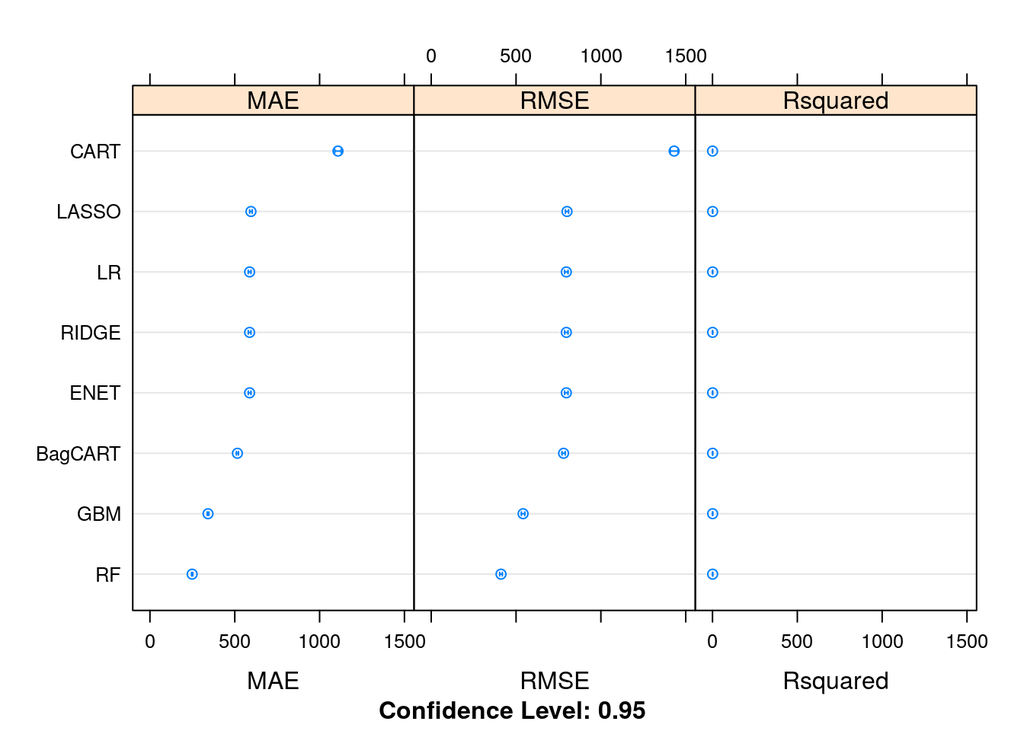

```r
dotplot(results)
```

```r
cat('The average RMSE from all models is:',
    mean(c(results$values$`LR~RMSE`,results$values$`RIDGE~RMSE`,results$values$`LASSO~RMSE`,results$values$`ENET~RMSE`,results$values$`CART~RMSE`,results$values$`BagCART~RMSE`,results$values$`RF~RMSE`,results$values$`GBM~RMSE`)),'\n')
```

```
## The average RMSE from all models is: 794.2948
```

```r
cat('Total training time for all models:',proc.time()-startModeling)
```

```
## Total training time for all models: 78392.81 155.562 77686.59 0 0
```

## 5. Improve Accuracy or Results

After we achieve a short list of machine learning algorithms with good level of accuracy, we can leverage ways to improve the accuracy of the models.

### 5.a) Algorithm Tuning

Finally, we will tune the best-performing algorithms from each group further and see whether we can get more accuracy out of them.

```r
# Tuning algorithm #1 - Random Forest
if (notifyStatus) email_notify(paste("Algorithm #1 tuning has begun!",date()))
```

```
## [1] "Java-Object{org.apache.commons.mail.SimpleEmail@e25b2fe}"
```

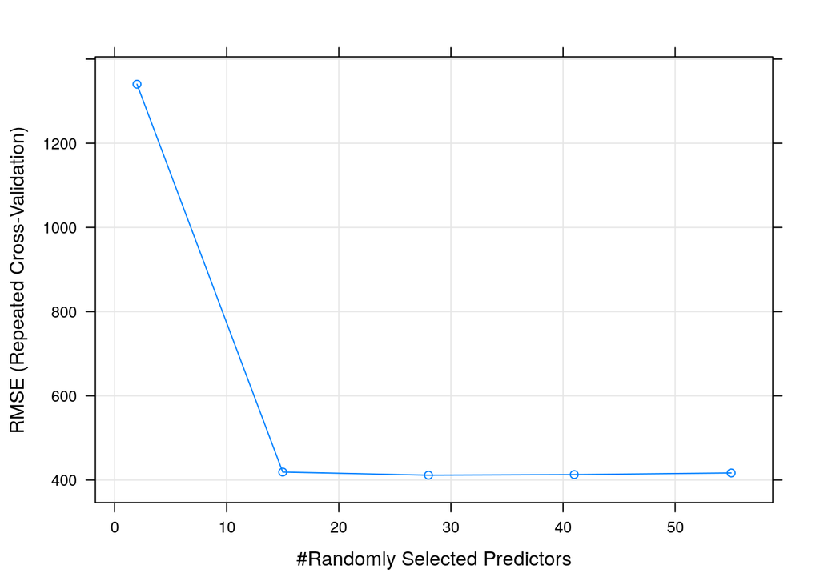

```r
startTimeModule <- proc.time()
set.seed(seedNum)
grid <- expand.grid(mtry = c(2,15,28,41,55))
fit.final1 <- train(targetVar~., data=Xy_train, method="rf", metric=metricTarget, tuneGrid=grid, trControl=control)
plot(fit.final1)
```

```r
print(fit.final1)
```

```
## Random Forest
##
## 36154 samples
##     9 predictor
##
## No pre-processing
## Resampling: Cross-Validated (10 fold, repeated 1 times)
## Summary of sample sizes: 32539, 32539, 32539, 32539, 32538, 32538, ...
## Resampling results across tuning parameters:
##
##   mtry  RMSE       Rsquared   MAE
##    2    1340.3337  0.8090443  1152.3356
##   15     418.8946  0.9556364   259.5537
##   28     411.4516  0.9570789   248.7933
##   41     412.9226  0.9567682   248.6756
##   55     416.7367  0.9559661   249.8432
##
## RMSE was used to select the optimal model using the smallest value.
## The final value used for the model was mtry = 28.
```

```r
proc.time()-startTimeModule
```

```
##       user     system    elapsed
## 115049.208     25.008 115355.104
```

```r
if (notifyStatus) email_notify(paste("Algorithm #1 tuning completed!",date()))
```

```
## [1] "Java-Object{org.apache.commons.mail.SimpleEmail@598067a5}"
```

```r
# Tuning algorithm #2 - Gradient Boosting
if (notifyStatus) email_notify(paste("Algorithm #2 tuning has begun!",date()))
```

```
## [1] "Java-Object{org.apache.commons.mail.SimpleEmail@4cf777e8}"
```

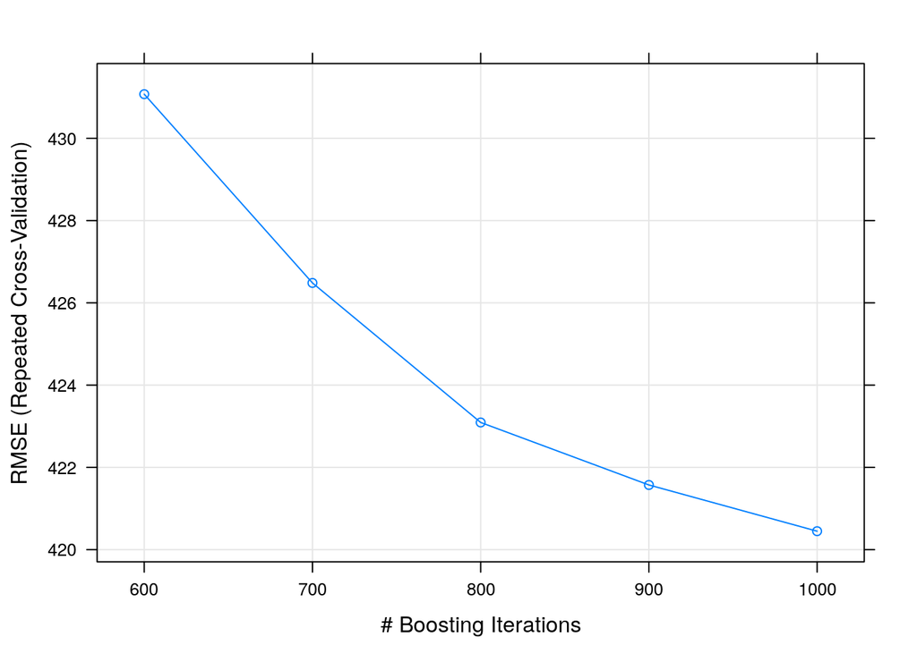

```r
startTimeModule <- proc.time()
set.seed(seedNum)
grid <- expand.grid(nrounds=c(600,700,800,900,1000), max_depth=3, eta=0.4, gamma=0, colsample_bytree=0.8, min_child_weight=1, subsample=0.5)
fit.final2 <- train(targetVar~., data=Xy_train, method="xgbTree", metric=metricTarget, tuneGrid=grid, trControl=control, verbose=F)
plot(fit.final2)
```

```r
print(fit.final2)
```

```
## eXtreme Gradient Boosting
##
## 36154 samples
##     9 predictor
##
## No pre-processing
## Resampling: Cross-Validated (10 fold, repeated 1 times)
## Summary of sample sizes: 32539, 32539, 32539, 32539, 32538, 32538, ...
## Resampling results across tuning parameters:
##
##   nrounds  RMSE      Rsquared   MAE
##    600     431.0727  0.9529052  279.9463
##    700     426.4839  0.9538867  277.7873
##    800     423.0918  0.9546071  276.3274
##    900     421.5724  0.9549310  276.4826
##   1000     420.4485  0.9551722  275.8382
##
## Tuning parameter 'max_depth' was held constant at a value of 3
##  0.8
## Tuning parameter 'min_child_weight' was held constant at a value of
##  1
## Tuning parameter 'subsample' was held constant at a value of 0.5
## RMSE was used to select the optimal model using the smallest value.
## The final values used for the model were nrounds = 1000, max_depth =
##  3, eta = 0.4, gamma = 0, colsample_bytree = 0.8, min_child_weight = 1
##  and subsample = 0.5.
```

```r
proc.time()-startTimeModule
```

```
##    user  system elapsed
## 551.226   1.127 279.137
```

```r
if (notifyStatus) email_notify(paste("Algorithm #2 tuning completed!",date()))
```

```
## [1] "Java-Object{org.apache.commons.mail.SimpleEmail@3f49dace}"
```

### 5.d) Compare Algorithms After Tuning

```r
results <- resamples(list(RF=fit.final1, GBM=fit.final2))
summary(results)
```

```
##
## Call:
## summary.resamples(object = results)
##
## Models: RF, GBM
## Number of resamples: 10
##
## MAE
##         Min.  1st Qu.   Median     Mean  3rd Qu.     Max. NA's
## RF  241.5906 245.7053 248.7947 248.7933 252.4236 255.8205    0
## GBM 265.9591 273.4771 275.9911 275.8382 278.7945 285.2369    0
##
## RMSE
##         Min.  1st Qu.   Median     Mean  3rd Qu.     Max. NA's
## RF  395.5954 404.6960 409.4707 411.4516 415.7399 432.7330    0
## GBM 402.9518 412.9787 419.9049 420.4485 423.8453 447.1138    0
##
## Rsquared
##          Min.   1st Qu.    Median      Mean   3rd Qu.      Max. NA's
## RF  0.9520768 0.9562916 0.9572089 0.9570789 0.9583899 0.9607917    0
## GBM 0.9488543 0.9546174 0.9556050 0.9551722 0.9564375 0.9589638    0
```

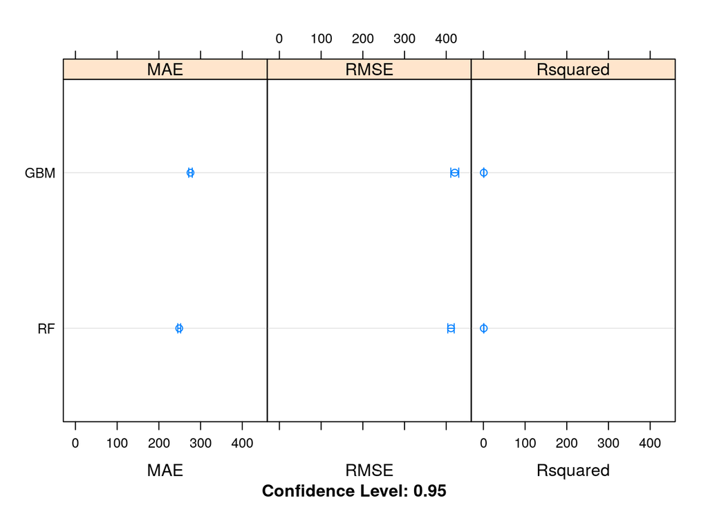

```r
dotplot(results)
```

## 6. Finalize Model and Present Results

Once we have narrow down to a model that we believe can make accurate predictions on unseen data, we are ready to finalize it. Finalizing a model may involve sub-tasks such as:

- Using an optimal model tuned to make predictions on unseen data.
- Creating a standalone model using the tuned parameters
- Saving an optimal model to file for later use.

```r
if (notifyStatus) email_notify(paste("Model Validation and Final Model Creation has begun!",date()))
```

```
## [1] "Java-Object{org.apache.commons.mail.SimpleEmail@56ef9176}"
```

### 6.a) Predictions on validation dataset

```r
predictions <- predict(fit.final1, newdata=Xy_test)
cat("The RMSE for the test data is:", RMSE(predictions, y_test),'\n')
```

```
## The RMSE for the test data is: 407.0208
```

```r
cat("The R2 score for the model is:", R2(predictions, y_test))
```

```
## The R2 score for the model is: 0.9581302
```

```r
predictions <- predict(fit.final2, newdata=Xy_test)
cat("The RMSE for the test data is:", RMSE(predictions, y_test),'\n')
```

```
## The RMSE for the test data is: 419.1784
```

```r
cat("The R2 score for the model is:", R2(predictions, y_test))
```

```
## The R2 score for the model is: 0.9556042
```

### 6.b) Create standalone model on entire training dataset

```r
startTimeModule <- proc.time()
set.seed(seedNum)

# Combining datasets to form a complete dataset that will be used to train the final model
Xy_complete <- rbind(Xy_train, Xy_test)

# library(xgboost)
# finalModel <- xgboost(data=Xy_complete, label=Xy_complete$targetVar, nrounds=900, max_depth=3, eta=0.4, gamma=0, colsample_bytree=0.8, min_child_weight=1, subsample=0.5)
# summary(finalModel)
proc.time()-startTimeModule
```

```
##    user  system elapsed
##   0.023   0.000   0.023
```

### 6.c) Save model for later use

```r
#saveRDS(finalModel, "./finalModel_Regression.rds")
```

```r
if (notifyStatus) email_notify(paste("Model Validation and Final Model Creation Completed!",date()))
```

```
## [1] "Java-Object{org.apache.commons.mail.SimpleEmail@5649fd9b}"
```

```r
proc.time()-startTimeScript
```

```
##       user     system    elapsed
## 194011.386    182.758 193357.619
```